# Warm-up 03: Basic Data Manipulation

Cindy Lo

9/15/2018

## Reading the Data Into R

```r
#https://github.com/ucb-stat133/stat133-fall-2018/raw/master/data/saratoga.txt
```

Do the data have a header containing the variable names?

- Yes! The headers include variable names (i.e. “Price”, “Lot Size”, “Waterfront”)

Are the values for an observation separated by a comma, blank, or tab?

- The values for an observation seem to be separated by a tab.

What are the parameters that are used to specify whether the data have a header? How are the values in a row separated?

- The parameter `header` is a logical value that indicates whether the file contains the names of the variables as its first line.
- `sep` is the field separator character. Values on each line of the file are separated by this separator. If `sep` = “”, which is the default for `read.table`, then the separator is ‘white space’.

```r
github <- "https://github.com/ucb-stat133/stat133-fall-2018/"
repo <- "raw/master/data/saratoga.txt"
house <- read.table(paste0(github,repo), header = TRUE, sep = "\t")
str(house)
```

```
## 'data.frame':    1728 obs. of  16 variables:
##  $ Price        : int  132500 181115 109000 155000 86060 120000 153000 170000 90000 122900 ...
##  $ Lot.Size     : num  0.09 0.92 0.19 0.41 0.11 0.68 0.4 1.21 0.83 1.94 ...
##  $ Waterfront   : int  0 0 0 0 0 0 0 0 0 0 ...
##  $ Age          : int  42 0 133 13 0 31 33 23 36 4 ...
##  $ Land.Value   : int  50000 22300 7300 18700 15000 14000 23300 14600 22200 21200 ...
##  $ New.Construct: int  0 0 0 0 1 0 0 0 0 0 ...
##  $ Central.Air  : int  0 0 0 0 1 0 0 0 0 0 ...
##  $ Fuel.Type    : int  3 2 2 2 2 2 4 4 3 2 ...
##  $ Heat.Type    : int  4 3 3 2 2 2 3 2 4 2 ...
##  $ Sewer.Type   : int  2 2 3 2 3 2 2 2 2 1 ...
##  $ Living.Area  : int  906 1953 1944 1944 840 1152 2752 1662 1632 1416 ...
##  $ Pct.College  : int  35 51 51 51 51 22 51 35 51 44 ...
##  $ Bedrooms     : int  2 3 4 3 2 4 4 4 3 3 ...
##  $ Fireplaces   : int  1 0 1 1 0 1 1 1 0 0 ...
##  $ Bathrooms    : num  1 2.5 1 1.5 1 1 1.5 1.5 1.5 1.5 ...
##  $ Rooms        : int  5 6 8 5 3 8 8 9 8 6 ...
```

## Examine price

```r
summary(house$Price)
```

```
##    Min. 1st Qu.  Median    Mean 3rd Qu.    Max.
##    5000  145000  189900  211967  259000  775000
```

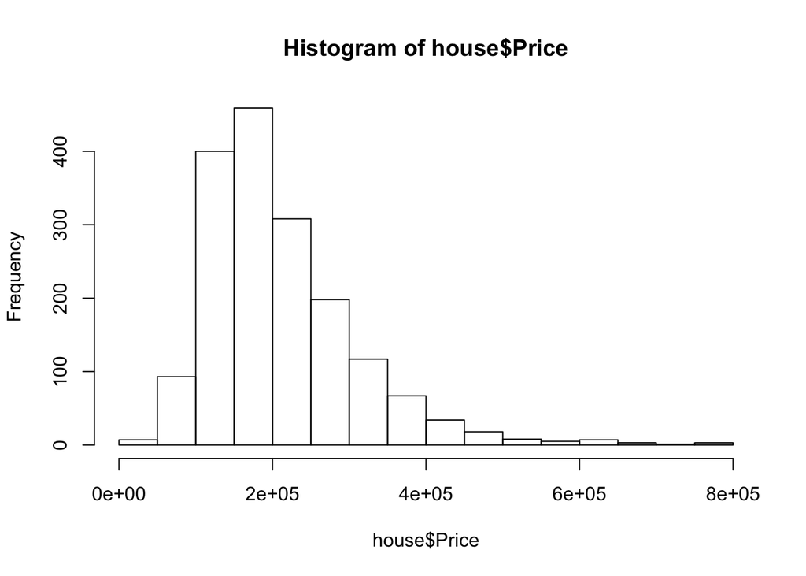

```r
hist(house$Price)
```

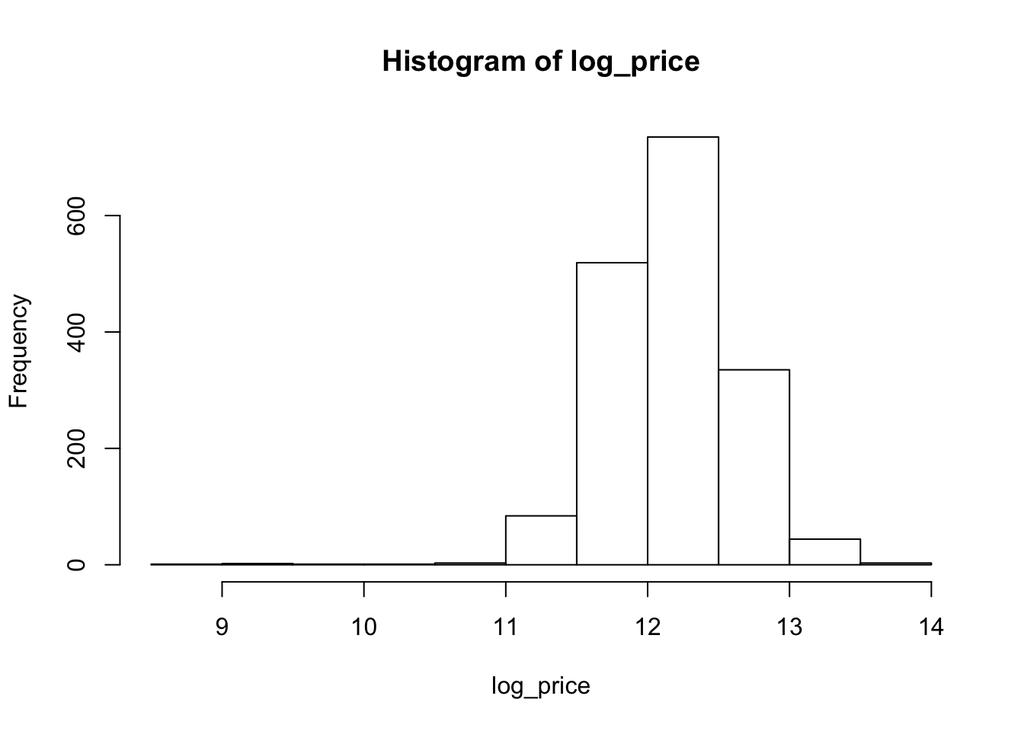

```r
log_price <- log(house$Price)
hist(log_price)
```

```r
cheap <- log_price < 10.5
sum(cheap)
```

```
## [1] 5
```

How many houses are what we call cheap?

- There are 5 houses where the log of the house price is under 10.5.

Use logical subsetting to print the values of all the variables for the cheap houses.

```r
log_price[log_price < 10.5]
```

```
## [1] 10.126631  9.903488  9.239899  9.239899  8.517193
```

Use the variable `cheap` to (logically) subset the data frame `house` and remove these rows from the data frame, replacing the existing data frame with a new one.

```r
house2 <- subset(house, cheap == FALSE)
```

## Explore Living Area

Do you find a similar issue with the living area?

```r
summary(house$Living.Area)
```

```
##    Min. 1st Qu.  Median    Mean 3rd Qu.    Max.
##     616    1300    1634    1755    2138    5228
```

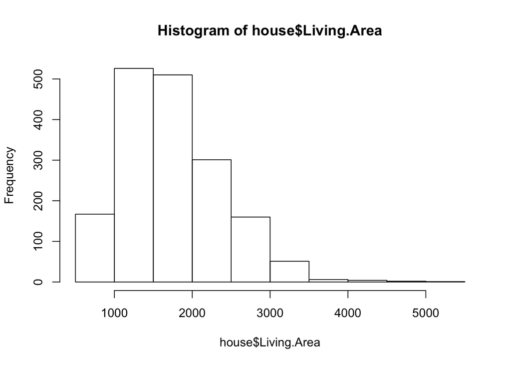

```r
hist(house$Living.Area)
```

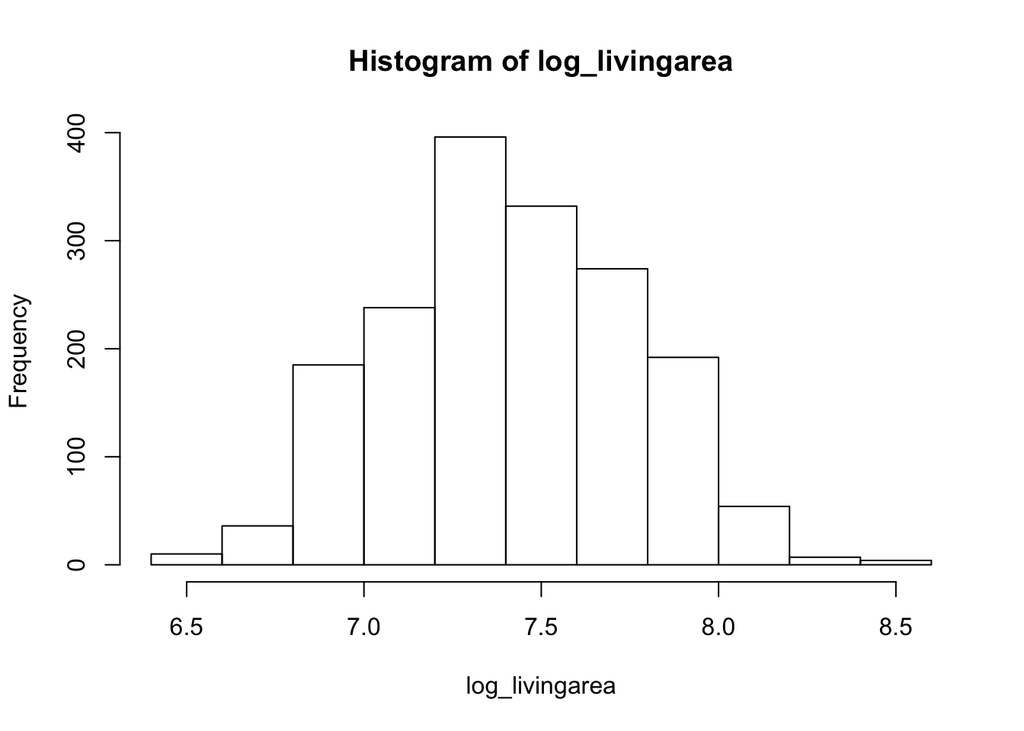

```r
log_livingarea <- log(house$Living.Area)
hist(log_livingarea)
```

## Transforming Variables into Factors

```r
BR <- house$Bedrooms
BR[BR > 5] <- 5
BR[BR < 2] <- 2
BR <- factor(BR, labels = c("2- BR", "3 BR", "4 BR", "5+ BR"))
```

```r
summary(house$Bedrooms)
```

```
##    Min. 1st Qu.  Median    Mean 3rd Qu.    Max.
##   1.000   3.000   3.000   3.155   4.000   7.000
```

```r
summary(BR)
```

```
## 2- BR  3 BR  4 BR 5+ BR
##   355   822   487    64
```

How does a summary of `BR` look different than a summary of `house$Bedrooms`?

- A summary of `house$Bedrooms` has a minimum and maximum value of 1 and 7, respectively, whereas a summary of `BR` has the total number of 2- BR, 3 BR, 4 BR, and 5+ BR.

## Plotting Price against Living Area

```r
br_colors <- house$Bedrooms
br_colors[br_colors > 5] <- 5
br_colors[br_colors < 2] <- 2

my_colors <- c("aquamarine3", "darkgoldenrod2", "coral2", "mediumorchid3")

br_colors[br_colors == 2] <- my_colors[1]
br_colors[br_colors == 3] <- my_colors[2]
br_colors[br_colors == 4] <- my_colors[3]
br_colors[br_colors == 5] <- my_colors[4]
```

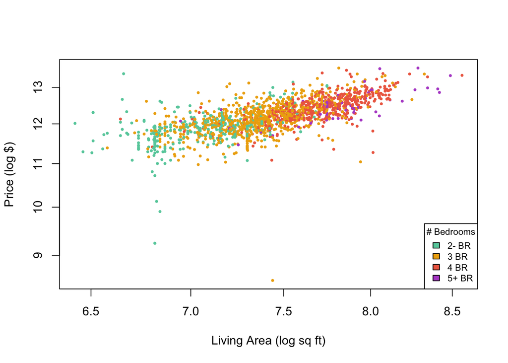

```r
plot(log_price ~ log_livingarea, data = house, log = "xy", main = "", xlab = "Living Area (log sq ft)", ylab = "Price (log $)", col = br_colors, pch = 19, cex = 0.4)

legend("bottomright", fill = my_colors, legend = levels(BR), title = "# Bedrooms", cex = 0.75)
```

## Number of Fireplaces

```r
FP <- house$Fireplaces
FP[FP > 1] <- 1
FP <- factor(FP, labels = c("None", "At least 1"))
```

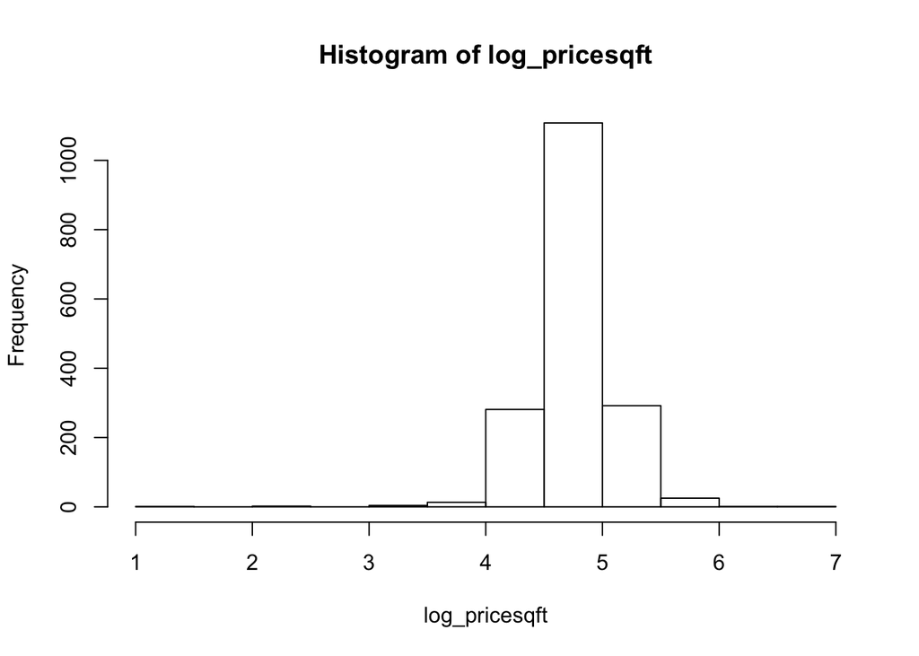

```r
pricesqft <- house$Price/house$Living.Area
log_pricesqft <- log(pricesqft)
hist(log_pricesqft)
```

```r
fp_colors <- house$Fireplaces
fp_colors[fp_colors > 1] <- 1
fp_colors[fp_colors == 0] <- my_colors[1]
fp_colors[fp_colors == 1] <- my_colors[2]
```

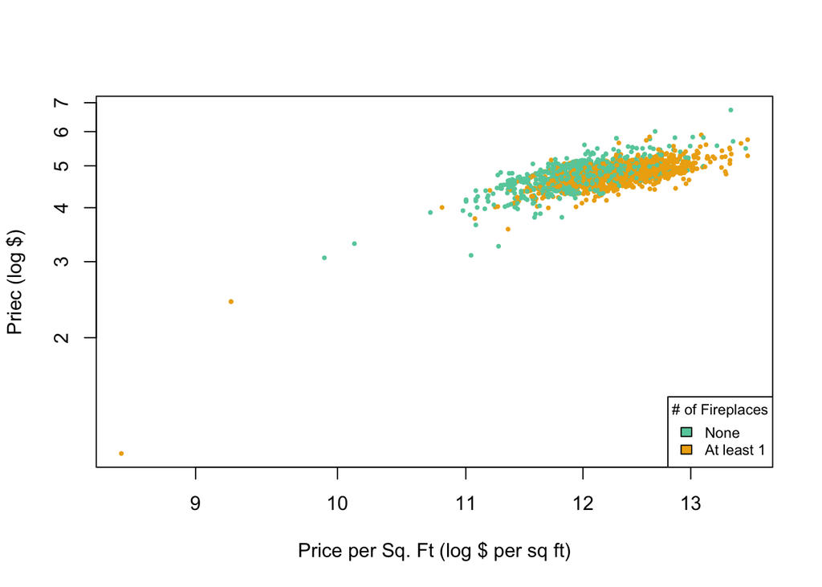

```r
plot(log_pricesqft ~ log_price, data = house, log = "xy", main = "", xlab = "Price per Sq. Ft (log $ per sq ft)", ylab = "Priec (log $)", col = fp_colors, pch = 19, cex = 0.4)

legend("bottomright", fill = my_colors, legend = levels(FP), title = "# of Fireplaces", cex = 0.75)
```

Are the houses with fireplaces generally more expensive than houses without?

What is the relationship between price per square foot and price?

- There seems to be a general positive trend between the price per square foot and the price. As one increases, the other also increases.

Can you explain why you might have this shape of relationship?

- The shape of the relationship may be due to how the more expensive a house is per square foot, the more the price of a house may increase.